# Spotify Analysis

Kyle Cohen, Declan Coyle, Nishant Dash, Evan Gresens, Angelina Ilijevski, Gahyun (Grace) Yoon

2023-12-12

# 1 Business Problem

What makes a successful song in terms of popularity? Popular songs with more streams mean more $ for artists and record labels. In the case of Spotify, the amount you can expect to receive lies between $0.003 to $0.005 per stream, or $3-5 dollars per thousand streams. What type of songs should artists and labels make to maximize their financial potential, and what songs should they choose to promote?

For each dollar of revenue earned on Spotify, 58.5 cents go to the owner of a song’s sound recording (usually a record label), Spotify keeps 29.38 cents, 6.12 cents go to whoever owns publishing rights (usually the songwriter) and 6 cents goes to whoever owns the mechanical rights (usually the songwriter), according to 2016 research by Manatt, Phelps & Phillips, a professional services firm.

With our work, we are hoping to help focus artist’s efforts when it comes to producing and promoting certain songs. We hope that with our model, an artist will be able to determine if one of their songs will be popular and then promote that song more than others. This could lead to an artist only promoting their most popular songs, and not wasting their budget on songs that will not be popular and therefore not bring them as much money.

# 2 Preparation

## 2.1 Data Cleaning

### 2.1.1 Clean Data

Cleaning our dataset is crucial for obtaining higher accuracies and kappas by removing unused variables or refactoring existing ones.

First we have to read our data.

```r
spotify_data <- read.csv("../spotify_songs.csv", stringsAsFactors = T)
```

We then remove all duplicate songs.

```r
spotify_data <- spotify_data[!duplicated(spotify_data$track_name), ]
summary(spotify_data)
```

```
##                    track_id
##  0017A6SJgTbfQVU2EtsPNo:    1
##  002xjHwzEx66OWFV2IP9dk:    1
##  004s3t0ONYlzxII9PLgU6z:    1
##  008MceT31RotUANsKuzy3L:    1
##  00bc7A2CLjp40XNd6ZPZNa:    1
##  00cqd6ZsSkLZqGMlQCR0Zo:    1
##  (Other)               :23444
##                                        track_name
##  '39 - 2011 Mix                             :    1
##  '74 - '75 (feat. Susan Tyler) - Radio Edit :    1
##  '98 Freestyle                              :    1
##  'Round And 'Round (Merry Go 'Round Of Love):    1
##  'Til the Cows Come Home                    :    1
##  (Other)                                    :23444
##  NA's                                       :    1
##                     track_artist   track_popularity
##  Queen                    :  111   Min.   : 0.00
##  Martin Garrix            :   68   1st Qu.:23.00
##  David Guetta             :   60   Median :43.00
##  Logic                    :   56   Mean   :39.74
##  Dimitri Vegas & Like Mike:   55   3rd Qu.:58.00
##  (Other)                  :23099   Max.   :98.00
##  NA's                     :    1
##                 track_album_id                     track_album_name
##  5fstCqs5NpIlF42VhPNv23:   29   Greatest Hits              :   96
##  5L1xcowSxwzFUSJzvyMp48:   27   Rock & Rios (Remastered)   :   29
##  5XCOTqG63V60nS82PmqMBe:   18   Ultimate Freestyle Mega Mix:   27
##  4VFG1DOuTeDMBjBLZT7hCK:   15   Asian Dreamer              :   18
##  6TBwXfQCeLoVIOW53dNLqz:   15   Gold                       :   18
##  246E5OvV4QXhPrGOSj7vdb:   14   (Other)                    :23261
##  (Other)               :23332   NA's                       :    1
##  track_album_release_date           playlist_name
##  2020-01-10:  173         Indie Poptimism  :  242
##  2019-12-06:  162         Permanent Wave   :  178
##  2019-11-22:  159         Hard Rock Workout:  164
##  2019-11-15:  153         Southern Hip Hop :  153
##  2013-01-01:  151         post teen pop    :  136
##  2019-12-13:  150         Dance Pop        :  132
##  (Other)   :22502         (Other)          :22445
```

[output cut: 25 more lines]

```
##  Min.   :0.0000   Min.   :0.0000000   Min.   :0.0000   Min.   :0.0000
##  1st Qu.:0.0148   1st Qu.:0.0000000   1st Qu.:0.0927   1st Qu.:0.3300
##  Median :0.0827   Median :0.0000192   Median :0.1270   Median :0.5130
##  Mean   :0.1811   Mean   :0.0940709   Mean   :0.1916   Mean   :0.5114
##  3rd Qu.:0.2660   3rd Qu.:0.0069600   3rd Qu.:0.2497   3rd Qu.:0.6950
##  Max.   :0.9940   Max.   :0.9940000   Max.   :0.9960   Max.   :0.9910
##
##      tempo         duration_ms
##  Min.   :  0.00   Min.   :  4000
##  1st Qu.: 99.97   1st Qu.:187200
##  Median :122.00   Median :216138
##  Mean   :121.08   Mean   :226109
##  3rd Qu.:134.78   3rd Qu.:254504
##  Max.   :239.44   Max.   :517810
##
```

We then remove all unnecessary variables such as IDs and names.

```r
spotify_data$track_id <- NULL
spotify_data$track_album_id <- NULL
spotify_data$playlist_id <- NULL
spotify_data$track_album_release_date <- NULL
spotify_data$track_name <- NULL
spotify_data$track_artist <- NULL
spotify_data$playlist_name <- NULL
spotify_data$track_album_name <- NULL
spotify_data$playlist_subgenre <- NULL # The genre has more general info
```

Next, we change the key variable to a factor.

```r
spotify_data$key <- as.factor(spotify_data$key)
summary(spotify_data)
```

```
##  track_popularity playlist_genre  danceability        energy
##  Min.   : 0.00    edm  :3817     Min.   :0.0000   Min.   :0.000175
##  1st Qu.:23.00    latin:3417     1st Qu.:0.5630   1st Qu.:0.578000
##  Median :43.00    pop  :4572     Median :0.6720   Median :0.720000
##  Mean   :39.74    r&b  :3400     Mean   :0.6552   Mean   :0.696644
##  3rd Qu.:58.00    rap  :4878     3rd Qu.:0.7620   3rd Qu.:0.841000
##  Max.   :98.00    rock :3366     Max.   :0.9830   Max.   :1.000000
##
##       key          loudness            mode         speechiness
##  1      :2827   Min.   :-46.448   Min.   :0.0000   Min.   :0.0000
##  0      :2510   1st Qu.: -8.341   1st Qu.:0.0000   1st Qu.:0.0412
##  7      :2413   Median : -6.285   Median :1.0000   Median :0.0637
##  9      :2196   Mean   : -6.848   Mean   :0.5667   Mean   :0.1103
##  11     :2127   3rd Qu.: -4.727   3rd Qu.:1.0000   3rd Qu.:0.1390
##  2      :2011   Max.   :  1.275   Max.   :1.0000   Max.   :0.9180
##  (Other):9366
##   acousticness    instrumentalness       liveness         valence
##  Min.   :0.0000   Min.   :0.0000000   Min.   :0.0000   Min.   :0.0000
##  1st Qu.:0.0148   1st Qu.:0.0000000   1st Qu.:0.0927   1st Qu.:0.3300
##  Median :0.0827   Median :0.0000192   Median :0.1270   Median :0.5130
##  Mean   :0.1811   Mean   :0.0940709   Mean   :0.1916   Mean   :0.5114
##  3rd Qu.:0.2660   3rd Qu.:0.0069600   3rd Qu.:0.2497   3rd Qu.:0.6950
##  Max.   :0.9940   Max.   :0.9940000   Max.   :0.9960   Max.   :0.9910
##
##      tempo         duration_ms
##  Min.   :  0.00   Min.   :  4000
##  1st Qu.: 99.97   1st Qu.:187200
##  Median :122.00   Median :216138
##  Mean   :121.08   Mean   :226109
##  3rd Qu.:134.78   3rd Qu.:254504
##  Max.   :239.44   Max.   :517810
##
```

```r
str(spotify_data)
```

```
## 'data.frame':    23450 obs. of  14 variables:
##  $ track_popularity: int  66 67 70 60 69 67 62 69 68 67 ...
##  $ playlist_genre  : Factor w/ 6 levels "edm","latin",..: 3 3 3 3 3 3 3 3 3 3 ...
##  $ danceability    : num  0.748 0.726 0.675 0.718 0.65 0.675 0.449 0.542 0.594 0.642 ...
##  $ energy          : num  0.916 0.815 0.931 0.93 0.833 0.919 0.856 0.903 0.935 0.818 ...
##  $ key             : Factor w/ 12 levels "0","1","2","3",..: 7 12 2 8 2 9 6 5 9 3 ...
##  $ loudness        : num  -2.63 -4.97 -3.43 -3.78 -4.67 ...
##  $ mode            : int  1 1 0 1 1 1 0 0 1 1 ...
##  $ speechiness     : num  0.0583 0.0373 0.0742 0.102 0.0359 0.127 0.0623 0.0434 0.0565 0.032 ...
##  $ acousticness    : num  0.102 0.0724 0.0794 0.0287 0.0803 0.0799 0.187 0.0335 0.0249 0.0567 ...
##  $ instrumentalness: num  0.00 4.21e-03 2.33e-05 9.43e-06 0.00 0.00 0.00 4.83e-06 3.97e-06 0.00 ...
##  $ liveness        : num  0.0653 0.357 0.11 0.204 0.0833 0.143 0.176 0.111 0.637 0.0919 ...
##  $ valence         : num  0.518 0.693 0.613 0.277 0.725 0.585 0.152 0.367 0.366 0.59 ...
##  $ tempo           : num  122 100 124 122 124 ...
##  $ duration_ms     : int  194754 162600 176616 169093 189052 163049 187675 207619 193187 253040 ...
```

We change the popularity field to be a binary variable. Songs that had popularity above the median are 1 and songs below are 0. By choosing the median, we ensure an almost 50/50 split in the data in terms of popularity.

```r
# median is 43 for track popularity
spotify_data$track_popularity <- ifelse(spotify_data$track_popularity >= 43,1,0)
summary(spotify_data$track_popularity)
```

```
##    Min. 1st Qu.  Median    Mean 3rd Qu.    Max.
##   0.000   0.000   1.000   0.502   1.000   1.000
```

```r
summary(spotify_data)
```

```
##  track_popularity playlist_genre  danceability        energy
##  Min.   :0.000    edm  :3817     Min.   :0.0000   Min.   :0.000175
##  1st Qu.:0.000    latin:3417     1st Qu.:0.5630   1st Qu.:0.578000
##  Median :1.000    pop  :4572     Median :0.6720   Median :0.720000
##  Mean   :0.502    r&b  :3400     Mean   :0.6552   Mean   :0.696644
##  3rd Qu.:1.000    rap  :4878     3rd Qu.:0.7620   3rd Qu.:0.841000
##  Max.   :1.000    rock :3366     Max.   :0.9830   Max.   :1.000000
##
##       key          loudness            mode         speechiness
##  1      :2827   Min.   :-46.448   Min.   :0.0000   Min.   :0.0000
##  0      :2510   1st Qu.: -8.341   1st Qu.:0.0000   1st Qu.:0.0412
##  7      :2413   Median : -6.285   Median :1.0000   Median :0.0637
##  9      :2196   Mean   : -6.848   Mean   :0.5667   Mean   :0.1103
##  11     :2127   3rd Qu.: -4.727   3rd Qu.:1.0000   3rd Qu.:0.1390
##  2      :2011   Max.   :  1.275   Max.   :1.0000   Max.   :0.9180
##  (Other):9366
##   acousticness    instrumentalness       liveness         valence
##  Min.   :0.0000   Min.   :0.0000000   Min.   :0.0000   Min.   :0.0000
##  1st Qu.:0.0148   1st Qu.:0.0000000   1st Qu.:0.0927   1st Qu.:0.3300
##  Median :0.0827   Median :0.0000192   Median :0.1270   Median :0.5130
##  Mean   :0.1811   Mean   :0.0940709   Mean   :0.1916   Mean   :0.5114
##  3rd Qu.:0.2660   3rd Qu.:0.0069600   3rd Qu.:0.2497   3rd Qu.:0.6950
##  Max.   :0.9940   Max.   :0.9940000   Max.   :0.9960   Max.   :0.9910
##
##      tempo         duration_ms
##  Min.   :  0.00   Min.   :  4000
##  1st Qu.: 99.97   1st Qu.:187200
##  Median :122.00   Median :216138
##  Mean   :121.08   Mean   :226109
##  3rd Qu.:134.78   3rd Qu.:254504
##  Max.   :239.44   Max.   :517810
##
```

### 2.1.2 Model Matrix

We produce a model matrix to get dummy variables and clean the names of variables. This will help when training our models, as it will remove any issues with column names that could cause our models to fail or produce exceptions in the training and prediction stages.

```r
spotifymm <- as.data.frame(model.matrix(~ . -1, spotify_data))
spotifymm <- clean_names(spotifymm)
str(spotifymm)
```

```
## 'data.frame':    23450 obs. of  29 variables:
##  $ track_popularity   : num  1 1 1 1 1 1 1 1 1 1 ...
##  $ playlist_genreedm  : num  0 0 0 0 0 0 0 0 0 0 ...
##  $ playlist_genrelatin: num  0 0 0 0 0 0 0 0 0 0 ...
##  $ playlist_genrepop  : num  1 1 1 1 1 1 1 1 1 1 ...
##  $ playlist_genrer_b  : num  0 0 0 0 0 0 0 0 0 0 ...
##  $ playlist_genrerap  : num  0 0 0 0 0 0 0 0 0 0 ...
##  $ playlist_genrerock : num  0 0 0 0 0 0 0 0 0 0 ...
##  $ danceability       : num  0.748 0.726 0.675 0.718 0.65 0.675 0.449 0.542 0.594 0.642 ...
##  $ energy             : num  0.916 0.815 0.931 0.93 0.833 0.919 0.856 0.903 0.935 0.818 ...
##  $ key1               : num  0 0 1 0 1 0 0 0 0 0 ...
##  $ key2               : num  0 0 0 0 0 0 0 0 0 1 ...
##  $ key3               : num  0 0 0 0 0 0 0 0 0 0 ...
##  $ key4               : num  0 0 0 0 0 0 0 1 0 0 ...
##  $ key5               : num  0 0 0 0 0 0 1 0 0 0 ...
##  $ key6               : num  1 0 0 0 0 0 0 0 0 0 ...
##  $ key7               : num  0 0 0 1 0 0 0 0 0 0 ...
##  $ key8               : num  0 0 0 0 0 1 0 0 1 0 ...
##  $ key9               : num  0 0 0 0 0 0 0 0 0 0 ...
##  $ key10              : num  0 0 0 0 0 0 0 0 0 0 ...
##  $ key11              : num  0 1 0 0 0 0 0 0 0 0 ...
##  $ loudness           : num  -2.63 -4.97 -3.43 -3.78 -4.67 ...
##  $ mode               : num  1 1 0 1 1 1 0 0 1 1 ...
##  $ speechiness        : num  0.0583 0.0373 0.0742 0.102 0.0359 0.127 0.0623 0.0434 0.0565 0.032 ...
##  $ acousticness       : num  0.102 0.0724 0.0794 0.0287 0.0803 0.0799 0.187 0.0335 0.0249 0.0567 ...
##  $ instrumentalness   : num  0.00 4.21e-03 2.33e-05 9.43e-06 0.00 0.00 0.00 4.83e-06 3.97e-06 0.00 ...
##  $ liveness           : num  0.0653 0.357 0.11 0.204 0.0833 0.143 0.176 0.111 0.637 0.0919 ...
##  $ valence            : num  0.518 0.693 0.613 0.277 0.725 0.585 0.152 0.367 0.366 0.59 ...
##  $ tempo              : num  122 100 124 122 124 ...
##  $ duration_ms        : num  194754 162600 176616 169093 189052 ...
```

### 2.1.3 Normalize

We then normalize the data. This will be particularly useful for models like KNN which require normalized data to train.

```r
normalize <- function(x) {
  return ((x - min(x)) / (max(x) - min(x)))
}

spotify_norm <- as.data.frame(lapply(spotifymm, normalize))
summary(spotify_norm)
```

```
##  track_popularity playlist_genreedm playlist_genrelatin playlist_genrepop
##  Min.   :0.000    Min.   :0.0000    Min.   :0.0000      Min.   :0.000
##  1st Qu.:0.000    1st Qu.:0.0000    1st Qu.:0.0000      1st Qu.:0.000
##  Median :1.000    Median :0.0000    Median :0.0000      Median :0.000
##  Mean   :0.502    Mean   :0.1628    Mean   :0.1457      Mean   :0.195
##  3rd Qu.:1.000    3rd Qu.:0.0000    3rd Qu.:0.0000      3rd Qu.:0.000
##  Max.   :1.000    Max.   :1.0000    Max.   :1.0000      Max.   :1.000
##  playlist_genrer_b playlist_genrerap playlist_genrerock  danceability
##  Min.   :0.000     Min.   :0.000     Min.   :0.0000     Min.   :0.0000
##  1st Qu.:0.000     1st Qu.:0.000     1st Qu.:0.0000     1st Qu.:0.5727
##  Median :0.000     Median :0.000     Median :0.0000     Median :0.6836
##  Mean   :0.145     Mean   :0.208     Mean   :0.1435     Mean   :0.6665
##  3rd Qu.:0.000     3rd Qu.:0.000     3rd Qu.:0.0000     3rd Qu.:0.7752
##  Max.   :1.000     Max.   :1.000     Max.   :1.0000     Max.   :1.0000
##      energy            key1             key2              key3
##  Min.   :0.0000   Min.   :0.0000   Min.   :0.00000   Min.   :0.00000
##  1st Qu.:0.5779   1st Qu.:0.0000   1st Qu.:0.00000   1st Qu.:0.00000
##  Median :0.7200   Median :0.0000   Median :0.00000   Median :0.00000
##  Mean   :0.6966   Mean   :0.1206   Mean   :0.08576   Mean   :0.02827
##  3rd Qu.:0.8410   3rd Qu.:0.0000   3rd Qu.:0.00000   3rd Qu.:0.00000
##  Max.   :1.0000   Max.   :1.0000   Max.   :1.00000   Max.   :1.00000
##       key4              key5              key6              key7
##  Min.   :0.00000   Min.   :0.00000   Min.   :0.00000   Min.   :0.0000
##  1st Qu.:0.00000   1st Qu.:0.00000   1st Qu.:0.00000   1st Qu.:0.0000
##  Median :0.00000   Median :0.00000   Median :0.00000   Median :0.0000
##  Mean   :0.06832   Mean   :0.08043   Mean   :0.07906   Mean   :0.1029
##  3rd Qu.:0.00000   3rd Qu.:0.00000   3rd Qu.:0.00000   3rd Qu.:0.0000
##  Max.   :1.00000   Max.   :1.00000   Max.   :1.00000   Max.   :1.0000
##       key8              key9             key10             key11
##  Min.   :0.00000   Min.   :0.00000   Min.   :0.00000   Min.   :0.0000
##  1st Qu.:0.00000   1st Qu.:0.00000   1st Qu.:0.00000   1st Qu.:0.0000
##  Median :0.00000   Median :0.00000   Median :0.00000   Median :0.0000
##  Mean   :0.07322   Mean   :0.09365   Mean   :0.07011   Mean   :0.0907
##  3rd Qu.:0.00000   3rd Qu.:0.00000   3rd Qu.:0.00000   3rd Qu.:0.0000
##  Max.   :1.00000   Max.   :1.00000   Max.   :1.00000   Max.   :1.0000
##     loudness           mode         speechiness       acousticness
##  Min.   :0.0000   Min.   :0.0000   Min.   :0.00000   Min.   :0.00000
##  1st Qu.:0.7985   1st Qu.:0.0000   1st Qu.:0.04488   1st Qu.:0.01489
##  Median :0.8416   Median :1.0000   Median :0.06939   Median :0.08320
##  Mean   :0.8298   Mean   :0.5667   Mean   :0.12018   Mean   :0.18222
##  3rd Qu.:0.8742   3rd Qu.:1.0000   3rd Qu.:0.15142   3rd Qu.:0.26761
##  Max.   :1.0000   Max.   :1.0000   Max.   :1.00000   Max.   :1.00000
##  instrumentalness       liveness          valence           tempo
##  Min.   :0.0000000   Min.   :0.00000   Min.   :0.0000   Min.   :0.0000
##  1st Qu.:0.0000000   1st Qu.:0.09307   1st Qu.:0.3330   1st Qu.:0.4175
##  Median :0.0000193   Median :0.12751   Median :0.5177   Median :0.5095
##  Mean   :0.0946388   Mean   :0.19236   Mean   :0.5160   Mean   :0.5057
##  3rd Qu.:0.0070020   3rd Qu.:0.25075   3rd Qu.:0.7013   3rd Qu.:0.5629
##  Max.   :1.0000000   Max.   :1.00000   Max.   :1.0000   Max.   :1.0000
##   duration_ms
##  Min.   :0.0000
##  1st Qu.:0.3566
##  Median :0.4129
##  Mean   :0.4323
##  3rd Qu.:0.4875
##  Max.   :1.0000
```

## 2.2 Train and Test Split

We will make our initial test and train split by partitioning our data equally (50% for training, 50% for testing). This way, we have enough data for training purposes and sufficient data for testing our models; using less of the dataset to train prevents overfitting of our models that could result from training models with a overly high proportion of data from the dataset.

```r
train_percentage <- 0.5
set.seed(12345)
train_rows <- sample(1:nrow(spotify_data), train_percentage * nrow(spotify_data))

spotify_train <- spotify_data[train_rows, ]
spotify_test <- spotify_data[-train_rows, ]

spotify_mm_train <- spotifymm[train_rows, ]
spotify_mm_test <- spotifymm[-train_rows, ]

spotify_norm_train <- spotify_norm[train_rows, ]
spotify_norm_test <- spotify_norm[-train_rows, ]

spotify_norm_train_x <- spotify_norm_train[, -match("track_popularity", names(spotify_norm_train))]
spotify_norm_train_y <- spotify_norm_train[, match("track_popularity", names(spotify_norm_train))]
spotify_norm_test_x <- spotify_norm_test[, -match("track_popularity", names(spotify_norm_test))]
spotify_norm_test_y <- spotify_norm_test[, match("track_popularity", names(spotify_norm_test))]
```

# 3 Initial Models

## 3.1 Logistic Regression

Logistic regression is a supervised learning algorithm which uses logistic functions to make predictions about an outcome, which in this case is track popularity.

### 3.1.1 Base Model

First, we build our base model by simply putting all variables into account.

```r
logistic_basemodel <- glm(track_popularity ~ ., data =spotify_train)
summary(logistic_basemodel)
```

```
##
## Call:
## glm(formula = track_popularity ~ ., data = spotify_train)
##
## Coefficients:
##                       Estimate Std. Error t value Pr(>|t|)
## (Intercept)          6.856e-01  5.955e-02  11.513  < 2e-16 ***
## playlist_genrelatin  2.150e-01  1.742e-02  12.347  < 2e-16 ***
## playlist_genrepop    2.742e-01  1.600e-02  17.142  < 2e-16 ***
## playlist_genrer&b    1.160e-01  1.821e-02   6.370 1.96e-10 ***
## playlist_genrerap    2.201e-01  1.678e-02  13.120  < 2e-16 ***
## playlist_genrerock   2.686e-01  1.861e-02  14.436  < 2e-16 ***
## danceability         1.760e-01  3.808e-02   4.623 3.83e-06 ***
## energy              -3.334e-01  4.075e-02  -8.182 3.08e-16 ***
## key1                 3.901e-03  1.875e-02   0.208 0.835156
## key2                -1.963e-02  2.048e-02  -0.959 0.337764
## key3                 1.062e-03  3.022e-02   0.035 0.971981
## key4                -8.174e-03  2.205e-02  -0.371 0.710798
## key5                -2.885e-03  2.117e-02  -0.136 0.891607
## key6                -8.692e-03  2.091e-02  -0.416 0.677671
## key7                -2.366e-02  1.925e-02  -1.229 0.218979
## key8                 4.249e-02  2.106e-02   2.017 0.043710 *
## key9                -1.981e-02  1.984e-02  -0.998 0.318292
## key10               -5.447e-05  2.200e-02  -0.002 0.998025
## key11                1.098e-02  2.019e-02   0.544 0.586512
## loudness             1.872e-02  2.156e-03   8.680  < 2e-16 ***
## mode                 2.377e-03  9.517e-03   0.250 0.802753
## speechiness         -7.216e-02  4.922e-02  -1.466 0.142603
## acousticness         8.219e-02  2.414e-02   3.405 0.000665 ***
## instrumentalness    -9.602e-02  2.098e-02  -4.576 4.79e-06 ***
## liveness            -2.447e-02  2.902e-02  -0.843 0.399098
## valence             -2.186e-02  2.229e-02  -0.981 0.326704
## tempo                6.047e-04  1.724e-04   3.507 0.000455 ***
## duration_ms         -7.802e-07  7.598e-08 -10.268  < 2e-16 ***
## ---
## Signif. codes:  0 '***' 0.001 '**' 0.01 '*' 0.05 '.' 0.1 ' ' 1
##
## (Dispersion parameter for gaussian family taken to be 0.2314004)
##
##     Null deviance: 2931.0  on 11724  degrees of freedom
## Residual deviance: 2706.7  on 11697  degrees of freedom
## AIC: 16143
##
## Number of Fisher Scoring iterations: 2
```

```r
logistic_base_prediction <- predict(logistic_basemodel, spotify_test, type = "response")
summary(logistic_base_prediction)
```

```
##    Min. 1st Qu.  Median    Mean 3rd Qu.    Max.
## -0.1629  0.4200  0.5302  0.5033  0.6018  0.9165
```

```r
logistic_base_pred <- ifelse(logistic_base_prediction >0.53,1,0)
summary(logistic_base_pred)
```

```
##    Min. 1st Qu.  Median    Mean 3rd Qu.    Max.
##  0.0000  0.0000  1.0000  0.5004  1.0000  1.0000
```

We then evaluate the data with said confusion matrix. Because we choose the median as a threshold, the numbers of false negative and false positive are very close to each other. We do want false negative to be a little lower in the business aspect, but we will consider such in the stacked model. As a result, we get an accuracy of 0.6115 and kappa of 0.223.

```r
confusionMatrix(as.factor(logistic_base_pred), as.factor(spotify_test$track_popularity))
```

```
## Confusion Matrix and Statistics
##
##           Reference
## Prediction    0    1
##          0 3583 2275
##          1 2280 3587
##
##                Accuracy : 0.6115
##                  95% CI : (0.6026, 0.6204)
##     No Information Rate : 0.5
##     P-Value [Acc > NIR] : <2e-16
##
##                   Kappa : 0.223
##
##  Mcnemar's Test P-Value : 0.9527
##
##             Sensitivity : 0.6111
##             Specificity : 0.6119
##          Pos Pred Value : 0.6116
##          Neg Pred Value : 0.6114
##              Prevalence : 0.5000
##          Detection Rate : 0.3056
##    Detection Prevalence : 0.4996
##       Balanced Accuracy : 0.6115
##
##        'Positive' Class : 0
##
```

### 3.1.2 Improved Model

We attempted to improve our model by only taking statistically significant variables in the base model into account.

```r
improved_logisitic = glm(track_popularity ~ playlist_genre*danceability*energy*loudness + playlist_genre*acousticness*instrumentalness*tempo*duration_ms, data = spotify_train)
```

We then predict the test data using the improved logistic regression model.

```r
logistic_improved_prob <- predict(improved_logisitic, spotify_test, type = "response")
summary(logistic_improved_prob) # prediction negative?
```

```
##    Min. 1st Qu.  Median    Mean 3rd Qu.    Max.
## -1.6762  0.4134  0.5251  0.5038  0.6147  1.7179
```

```r
logistic_improved_pred <- ifelse(logistic_improved_prob >0.5251,1,0) # median
summary(logistic_improved_pred)
```

```
##    Min. 1st Qu.  Median    Mean 3rd Qu.    Max.
##     0.0     0.0     1.0     0.5     1.0     1.0
```

After going through the same process as the base model, we found the this model was in fact an improvement from the base model as the accuracy and the kappa value are both higher than the base model(0.6115 -> 0.6171 / 0.223 -> 0.2343).

```r
confusionMatrix(as.factor(logistic_improved_pred), as.factor(spotify_test$track_popularity))
```

```
## Confusion Matrix and Statistics
##
##           Reference
## Prediction    0    1
##          0 3618 2244
##          1 2245 3618
##
##                Accuracy : 0.6171
##                  95% CI : (0.6083, 0.626)
##     No Information Rate : 0.5
##     P-Value [Acc > NIR] : <2e-16
##
##                   Kappa : 0.2343
##
##  Mcnemar's Test P-Value : 1
##
##             Sensitivity : 0.6171
##             Specificity : 0.6172
##          Pos Pred Value : 0.6172
##          Neg Pred Value : 0.6171
##              Prevalence : 0.5000
##          Detection Rate : 0.3086
##    Detection Prevalence : 0.5000
##       Balanced Accuracy : 0.6171
##
##        'Positive' Class : 0
##
```

Therefore, we are going to use the improved model in the stacked model to maximized accuracy and kappa.

### 3.1.3 KNN

K-Nearest Neighbors models work by finding the k nearest neighbors present in the dataset to an input data point and using a majority voting algorithm to determine the final classification of that point.

We use the train function that is used in model tuning to find best possible k value between 1 and 150. As a result, we get k = 136.

```r
ctrl <- trainControl(method = "cv", number = 10)

knn_train <- train(spotify_norm_train_x, as.factor(spotify_norm_train_y), method = "knn", tuneGrid = data.frame(k = seq(1, 150, by = 5)), trControl = ctrl)
best_k <- knn_train$bestTune$k
```

Although we calculated the best k, we tested different numbers of k in case there was one with a higher accuracy and kappa.

```r
knn.m_5 <- knn(spotify_norm_train_x, spotify_norm_test_x, spotify_norm_train_y, k = 5, prob = T)
knn.m_7 <- knn(spotify_norm_train_x, spotify_norm_test_x, spotify_norm_train_y, k = 7, prob = T)
knn.m_9 <- knn(spotify_norm_train_x, spotify_norm_test_x, spotify_norm_train_y, k = 9, prob = T)
knn.m_100 <- knn(spotify_norm_train_x, spotify_norm_test_x, spotify_norm_train_y, k = 100, prob = T)
knn.m_best_k <- knn(spotify_norm_train_x, spotify_norm_test_x, spotify_norm_train_y, k = 136, prob = T)
knn.m_150 <- knn(spotify_norm_train_x, spotify_norm_test_x, spotify_norm_train_y, k = 150, prob = T)
knn.m_200 <- knn(spotify_norm_train_x, spotify_norm_test_x, spotify_norm_train_y, k = 200, prob = T)
```

As we predicted, out of the values (i.e. 5, 7, 9, etc) we tested, the accuracy and the kappa was the highest when k = 136 when we evaluated our models using the confusion matrix (which can be found in the next section). This is because the hyperparameter tuning step above already accounted for models with the above manually selected k values and evidently identified that they did not yield favorable model performance.

#### 3.1.3.1 Confusion Matrices

##### K=5

```r
confusionMatrix(as.factor(knn.m_5), as.factor(spotify_norm_test_y)) # kappa = 0.133
```

```
## Confusion Matrix and Statistics
##
##           Reference
## Prediction    0    1
##          0 3105 2324
##          1 2758 3538
##
##                Accuracy : 0.5666
##                  95% CI : (0.5575, 0.5756)
##     No Information Rate : 0.5
##     P-Value [Acc > NIR] : < 2.2e-16
##
##                   Kappa : 0.1331
##
##  Mcnemar's Test P-Value : 1.248e-09
##
##             Sensitivity : 0.5296
##             Specificity : 0.6035
##          Pos Pred Value : 0.5719
##          Neg Pred Value : 0.5619
##              Prevalence : 0.5000
##          Detection Rate : 0.2648
##    Detection Prevalence : 0.4630
##       Balanced Accuracy : 0.5666
##
##        'Positive' Class : 0
##
```

##### K=7

```r
confusionMatrix(as.factor(knn.m_7), as.factor(spotify_norm_test_y)) # kappa = 0.1418
```

```
## Confusion Matrix and Statistics
##
##           Reference
## Prediction    0    1
##          0 3076 2244
##          1 2787 3618
##
##                Accuracy : 0.5709
##                  95% CI : (0.5619, 0.5799)
##     No Information Rate : 0.5
##     P-Value [Acc > NIR] : < 2.2e-16
##
##                   Kappa : 0.1418
##
##  Mcnemar's Test P-Value : 2.149e-14
##
##             Sensitivity : 0.5246
##             Specificity : 0.6172
##          Pos Pred Value : 0.5782
##          Neg Pred Value : 0.5649
##              Prevalence : 0.5000
##          Detection Rate : 0.2623
##    Detection Prevalence : 0.4537
##       Balanced Accuracy : 0.5709
##
##        'Positive' Class : 0
##
```

##### K=9

```r
confusionMatrix(as.factor(knn.m_9), as.factor(spotify_norm_test_y)) # kappa = 0.1439
```

```
## Confusion Matrix and Statistics
##
##           Reference
## Prediction    0    1
##          0 3054 2211
##          1 2809 3651
##
##                Accuracy : 0.5719
##                  95% CI : (0.5628, 0.5808)
##     No Information Rate : 0.5
##     P-Value [Acc > NIR] : < 2.2e-16
##
##                   Kappa : 0.1437
##
##  Mcnemar's Test P-Value : < 2.2e-16
##
##             Sensitivity : 0.5209
##             Specificity : 0.6228
##          Pos Pred Value : 0.5801
##          Neg Pred Value : 0.5652
##              Prevalence : 0.5000
##          Detection Rate : 0.2605
##    Detection Prevalence : 0.4490
##       Balanced Accuracy : 0.5719
##
##        'Positive' Class : 0
##
```

##### K=100

```r
confusionMatrix(as.factor(knn.m_100), as.factor(spotify_norm_test_y)) # kappa = 0.1719
```

```
## Confusion Matrix and Statistics
##
##           Reference
## Prediction    0    1
##          0 2633 1604
##          1 3230 4258
##
##                Accuracy : 0.5877
##                  95% CI : (0.5787, 0.5966)
##     No Information Rate : 0.5
##     P-Value [Acc > NIR] : < 2.2e-16
##
##                   Kappa : 0.1755
##
##  Mcnemar's Test P-Value : < 2.2e-16
##
##             Sensitivity : 0.4491
##             Specificity : 0.7264
##          Pos Pred Value : 0.6214
##          Neg Pred Value : 0.5686
##              Prevalence : 0.5000
##          Detection Rate : 0.2246
##    Detection Prevalence : 0.3614
##       Balanced Accuracy : 0.5877
##
##        'Positive' Class : 0
##
```

##### K=136

```r
confusionMatrix(as.factor(knn.m_best_k), as.factor(spotify_norm_test_y)) # kappa = 0.1814 accuracy 0.5887
```

```
## Confusion Matrix and Statistics
##
##           Reference
## Prediction    0    1
##          0 2371 1324
##          1 3492 4538
##
##                Accuracy : 0.5893
##                  95% CI : (0.5803, 0.5982)
##     No Information Rate : 0.5
##     P-Value [Acc > NIR] : < 2.2e-16
##
##                   Kappa : 0.1785
##
##  Mcnemar's Test P-Value : < 2.2e-16
##
##             Sensitivity : 0.4044
##             Specificity : 0.7741
##          Pos Pred Value : 0.6417
##          Neg Pred Value : 0.5651
##              Prevalence : 0.5000
##          Detection Rate : 0.2022
##    Detection Prevalence : 0.3151
##       Balanced Accuracy : 0.5893
##
##        'Positive' Class : 0
##
```

##### K=150

```r
confusionMatrix(as.factor(knn.m_150), as.factor(spotify_norm_test_y)) # kappa = 0.1758
```

```
## Confusion Matrix and Statistics
##
##           Reference
## Prediction    0    1
##          0 2314 1283
##          1 3549 4579
##
##                Accuracy : 0.5879
##                  95% CI : (0.5789, 0.5968)
##     No Information Rate : 0.5
##     P-Value [Acc > NIR] : < 2.2e-16
##
##                   Kappa : 0.1758
##
##  Mcnemar's Test P-Value : < 2.2e-16
##
##             Sensitivity : 0.3947
##             Specificity : 0.7811
##          Pos Pred Value : 0.6433
##          Neg Pred Value : 0.5634
##              Prevalence : 0.5000
##          Detection Rate : 0.1974
##    Detection Prevalence : 0.3068
##       Balanced Accuracy : 0.5879
##
##        'Positive' Class : 0
##
```

##### K=200

```r
confusionMatrix(as.factor(knn.m_200), as.factor(spotify_norm_test_y)) # kappa = 0.1756
```

```
## Confusion Matrix and Statistics
##
##           Reference
## Prediction    0    1
##          0 2265 1223
##          1 3598 4639
##
##                Accuracy : 0.5888
##                  95% CI : (0.5799, 0.5978)
##     No Information Rate : 0.5
##     P-Value [Acc > NIR] : < 2.2e-16
##
##                   Kappa : 0.1777
##
##  Mcnemar's Test P-Value : < 2.2e-16
##
##             Sensitivity : 0.3863
##             Specificity : 0.7914
##          Pos Pred Value : 0.6494
##          Neg Pred Value : 0.5632
##              Prevalence : 0.5000
##          Detection Rate : 0.1932
##    Detection Prevalence : 0.2975
##       Balanced Accuracy : 0.5888
##
##        'Positive' Class : 0
##
```

We obtain the probability values of the KNN prediction instead of the binary values so that we can have more of an accurate prediction in the stacked model.

We believe that we could have obtained higher accuracies and kappa values for KNN using fewer features; this is because as the number of features increases, more data is needed to strengthen the classification of the given input data point, thus adhering to the curse of dimensionality in KNN model training.

In the future, we would prefer to identify the most meaningful features associated with track popularity and possibly gather more song data as the number of songs available on Spotify increases.

```r
knn_prediction <- knn.m_best_k
knn_prob <- attr(knn_prediction, which = "prob")
```

For now, we will use the probability predictions for KNN with k = 136 in our stacked model as its overall performance mirrors those of other models and its imperfect predictability may have just been a result of using insufficient data in the training set.

## 3.2 ANN

Artificial Neural Networks (ANNs) are models that conduct the training process by using a set of specified hidden nodes which link with the given input nodes and the final output node. The input nodes take in the training data and initiate ANN’s training process which requires the ANN to learn weights that connect the input nodes to the hidden nodes as well as the hidden nodes to the output node. The output node is a singular prediction of the classification or value predicted by the model for the given inputs.

The goal of ANNs is to learn these edge weights to find relationships present in the incoming dataset. In this problem, our goal is to have the ANN model understand the relationships between all variables in the dataset through weights in order to predict track popularity for a song with certain specified attributes.

The quickest way to train an ANN on this dataset is to simply use a small number of hidden layers, as it would require the ANN to learn fewer weights between variables. However, in order to obtain higher accuracy with our model, we want to identify stronger relationships between the input, hidden, and output nodes; thus, we settled on a more complex configuration of hidden nodes, the first hidden layer containing 10 hidden nodes and the second hidden layer containing 6.

We then build the base model with these parameters and predict track popularity with the base model. Notice that we increase the step max to 1e9 instead of the default parameter. The reason for this was to increase the maximum training steps for the ANN in order to be more confident that the model will converge.

Indeed, the ANN model converged after about 1.26 days of training and 8 million iterations.

```r
set.seed(12345)
ann_model <- neuralnet(track_popularity ~ ., data = spotify_norm_train, hidden = c(10, 6), stepmax = 1e9, lifesign = "full")
```

To use the confusion matrix to evaluate our model, we change the ANN prediction into a binary data, using the median as a threshold.

```r
ann_prediction <- predict(ann_model, spotify_norm_test)
ann_pred_binary <- ifelse(ann_prediction > median(ann_prediction), 1, 0)
ann_confusion <- confusionMatrix(as.factor(ann_pred_binary), as.factor(spotify_norm_test$track_popularity), positive = "1")
ann_confusion
```

```
## Confusion Matrix and Statistics
##
##           Reference
## Prediction    0    1
##          0 3441 2422
##          1 2422 3440
##
##                Accuracy : 0.5869
##                  95% CI : (0.5779, 0.5958)
##     No Information Rate : 0.5
##     P-Value [Acc > NIR] : <2e-16
##
##                   Kappa : 0.1737
##
##  Mcnemar's Test P-Value : 1
##
##             Sensitivity : 0.5868
##             Specificity : 0.5869
##          Pos Pred Value : 0.5868
##          Neg Pred Value : 0.5869
##              Prevalence : 0.5000
##          Detection Rate : 0.2934
##    Detection Prevalence : 0.5000
##       Balanced Accuracy : 0.5869
##
##        'Positive' Class : 1
##
```

The median of the data was 0.5120237.

Using this threshold, we see that the confusion matrix gives us accuracy of 0.5868657and kappa of 0.1737313.

This accuracy and kappa are not ideal. We believe the reason for this may be that our configuration of hidden nodes and layers was not comprehensive enough to solidify strong and appropriate relationships (i.e. weights) between variables in our dataset. In the future, we plan to run more ANN models with more layers and different numbers of hidden nodes (ex. c(8, 6, 2, 4)). Due to runtime constraints, we were unable to retrieve model accuracies and kappas for more complex models, so we will use the above ANN in our stacked model.

## 3.3 SVM

Below, we train and test our data using the SVM model. We experiment with multiple different kernels, namely, laplacedot, rbfdot, and vanilladot.

```r
set.seed(12345)
spotify_svm_laplace <- ksvm(track_popularity ~ ., data = spotify_mm_train,
                          kernel = "laplacedot")
spotify_svm_rbf <- ksvm(track_popularity ~ ., data = spotify_mm_train,
                          kernel = "rbfdot")
spotify_svm <- ksvm(track_popularity ~ ., data = spotify_mm_train,
                          kernel = "vanilladot")
```

We then make predictions for track popularity using the laplacedot kernel for SVM. We examined the summary data (i.e. mean, median, etc) to determine a threshold with which to label a track as popular. We decided to use the median of the predicted values to determine the cut-off threshold for popularity.

```r
spotify_svm_pred_laplace <- predict(spotify_svm_laplace, spotify_mm_test)
summary(spotify_svm_pred_laplace)
```

```
##        V1
##  Min.   :-0.1341
##  1st Qu.: 0.3166
##  Median : 0.7476
##  Mean   : 0.6107
##  3rd Qu.: 0.8844
##  Max.   : 1.1134
```

For the laplacedot kernel, tracks with popularity scores greater than 0.7475719 are considered popular whereas tracks with popularity scores below this threshold are not popular.

We experimented with this threshold to gauge the changes in kappa and accuracy. As we increase this threshold, we increase the magnitude of false negatives; that is, a higher threshold (greater than the median) classifies fewer songs as popular when they actually are popular. With this in mind, it may make sense to increase this threshold, as it makes our predictions for popularity more strict, though it also yields lower kappa values which is not ideal. So, we decided to use a threshold equivalent to the median of the predicted SVM values for the laplacedot.

We applied this same ideology to the rbfdot and vanilladot kernels.

```r
spotify_svm_pred_laplace_binary <- ifelse(spotify_svm_pred_laplace >= median(spotify_svm_pred_laplace), 1, 0)
confusionMatrix(as.factor(spotify_svm_pred_laplace_binary), as.factor(spotify_mm_test$track_popularity), positive = "1")
```

```
## Confusion Matrix and Statistics
##
##           Reference
## Prediction    0    1
##          0 3566 2296
##          1 2297 3566
##
##                Accuracy : 0.6083
##                  95% CI : (0.5994, 0.6171)
##     No Information Rate : 0.5
##     P-Value [Acc > NIR] : <2e-16
##
##                   Kappa : 0.2165
##
##  Mcnemar's Test P-Value : 1
##
##             Sensitivity : 0.6083
##             Specificity : 0.6082
##          Pos Pred Value : 0.6082
##          Neg Pred Value : 0.6083
##              Prevalence : 0.5000
##          Detection Rate : 0.3041
##    Detection Prevalence : 0.5000
##       Balanced Accuracy : 0.6083
##
##        'Positive' Class : 1
##
```

The following code predicts track popularity using the SVM with rbfdot kernel.

```r
spotify_svm_pred_rbf <- predict(spotify_svm_rbf, spotify_mm_test)
summary(spotify_svm_pred_rbf)
```

```
##        V1
##  Min.   :-0.3215
##  1st Qu.: 0.2658
##  Median : 0.6711
##  Mean   : 0.5762
##  3rd Qu.: 0.8688
##  Max.   : 1.2374
```

The selected median value for the threshold is 0.6710816.

```r
spotify_svm_pred_rbf_binary <- ifelse(spotify_svm_pred_rbf >= median(spotify_svm_pred_rbf), 1, 0)
confusionMatrix(as.factor(spotify_svm_pred_rbf_binary), as.factor(spotify_mm_test$track_popularity))
```

```
## Confusion Matrix and Statistics
##
##           Reference
## Prediction    0    1
##          0 3575 2287
##          1 2288 3575
##
##                Accuracy : 0.6098
##                  95% CI : (0.6009, 0.6187)
##     No Information Rate : 0.5
##     P-Value [Acc > NIR] : <2e-16
##
##                   Kappa : 0.2196
##
##  Mcnemar's Test P-Value : 1
##
##             Sensitivity : 0.6098
##             Specificity : 0.6099
##          Pos Pred Value : 0.6099
##          Neg Pred Value : 0.6098
##              Prevalence : 0.5000
##          Detection Rate : 0.3049
##    Detection Prevalence : 0.5000
##       Balanced Accuracy : 0.6098
##
##        'Positive' Class : 0
##
```

The following code predicts track popularity using the SVM with vanilladot kernel.

```r
spotify_svm_pred_vanilla <- predict(spotify_svm, spotify_mm_test)
summary(spotify_svm_pred_vanilla)
```

```
##        V1
##  Min.   :0.04921
##  1st Qu.:0.05028
##  Median :0.94976
##  Mean   :0.67634
##  3rd Qu.:0.94992
##  Max.   :0.95044
```

The selected median value for the threshold is 0.9497564

```r
spotify_svm_pred_vanilla_binary <- ifelse(spotify_svm_pred_vanilla >= median(spotify_svm_pred_vanilla), 1, 0)
confusionMatrix(as.factor(spotify_svm_pred_vanilla_binary), as.factor(spotify_mm_test$track_popularity))
```

```
## Confusion Matrix and Statistics
##
##           Reference
## Prediction    0    1
##          0 3524 2336
##          1 2339 3526
##
##                Accuracy : 0.6013
##                  95% CI : (0.5923, 0.6102)
##     No Information Rate : 0.5
##     P-Value [Acc > NIR] : <2e-16
##
##                   Kappa : 0.2026
##
##  Mcnemar's Test P-Value : 0.9767
##
##             Sensitivity : 0.6011
##             Specificity : 0.6015
##          Pos Pred Value : 0.6014
##          Neg Pred Value : 0.6012
##              Prevalence : 0.5000
##          Detection Rate : 0.3006
##    Detection Prevalence : 0.4998
##       Balanced Accuracy : 0.6013
##
##        'Positive' Class : 0
##
```

From the above confusion matricies, we can see that the rbf kernel works the best with the spotify data as it has the highest kappa value.

We will use it in the combined model.

## 3.4 Decision Tree

A decision tree is a supervised machine learning model that follows a tree-like structure (including root nodes, leaf nodes, and branches) to make predictions according to answers selected for on previous sets of questions. More specifically, decision trees have splitting nodes which allow the model to make a decision about which branch it should select to gain the most information about a given input. Once the model reaches a leaf node, it returns the prediction for the given input. The training process for decision trees is responsible for creating this tree structure by finding relationships between splitting nodes and related child nodes.

```r
decision_tree <- C5.0(as.factor(track_popularity) ~ ., data = spotify_train)
```

We predict using the above model and evaluate the prediction using confusion matrix. This allows us to determine the distribution of false positives (i.e. songs that were predicted as popular but were actually not) and false negatives (i.e. songs that were not predicted as popular but actually were); it also allows us to understand the overall model performance and its predictability by examining its accuracy and kappa values.

```r
decision_predict <- predict(decision_tree, spotify_test)
confusionMatrix(as.factor(decision_predict), as.factor(spotify_test$track_popularity), positive = "1")
```

```
## Confusion Matrix and Statistics
##
##           Reference
## Prediction    0    1
##          0 3283 2340
##          1 2580 3522
##
##                Accuracy : 0.5804
##                  95% CI : (0.5714, 0.5893)
##     No Information Rate : 0.5
##     P-Value [Acc > NIR] : < 2.2e-16
##
##                   Kappa : 0.1608
##
##  Mcnemar's Test P-Value : 0.000656
##
##             Sensitivity : 0.6008
##             Specificity : 0.5600
##          Pos Pred Value : 0.5772
##          Neg Pred Value : 0.5839
##              Prevalence : 0.5000
##          Detection Rate : 0.3004
##    Detection Prevalence : 0.5204
##       Balanced Accuracy : 0.5804
##
##        'Positive' Class : 1
##
```

Our accuracy for this model 0.5804 (or 58%) and kappa is 0.1608. These values are relatively low compared to most of our other first level models like SVM and ANN. The reason for this may be that we are training the tree with too many variables that are not as relevant in making predictions about track popularity. Small changes in the training dataset could lead to drastically different results, for the configuration of splitting nodes and the overall tree structure would change.

Nevertheless, we decided to continue with this model, as its accuracy is relatively close to those obtained by other models and may train well when combined with other model predictions.

## 3.5 Random Forest

Building off from our construction of decision trees, random forests work by creating multiple decision trees to use an ensemble approach for making a final model prediction.

Here, we run the random forest algorithm without any model tuning.

```r
set.seed(12345)
rf <- randomForest(track_popularity ~ ., data = spotify_train)
rf_base_prediction <- predict(rf, spotify_test)
rf
```

```
##
## Call:
##  randomForest(formula = track_popularity ~ ., data = spotify_train)
##                Type of random forest: regression
##                      Number of trees: 500
## No. of variables tried at each split: 4
##
##           Mean of squared residuals: 0.2292429
##                     % Var explained: 8.3
```

```r
summary(rf_base_prediction)
```

```
##    Min. 1st Qu.  Median    Mean 3rd Qu.    Max.
##  0.0221  0.4242  0.5207  0.5081  0.6094  0.8835
```

The base random forest chose a regression tree model. That means our prediction is not binary. So we first converted our prediction to a binary variable based on the median prediction and then analyzed the confusion matrix.

```r
rf_base_prediction <- ifelse(0.5207 <= rf_base_prediction, 1, 0)
confusionMatrix(as.factor(rf_base_prediction), as.factor(spotify_test$track_popularity))
```

```
## Confusion Matrix and Statistics
##
##           Reference
## Prediction    0    1
##          0 3605 2256
##          1 2258 3606
##
##                Accuracy : 0.615
##                  95% CI : (0.6061, 0.6238)
##     No Information Rate : 0.5
##     P-Value [Acc > NIR] : <2e-16
##
##                   Kappa : 0.23
##
##  Mcnemar's Test P-Value : 0.9881
##
##             Sensitivity : 0.6149
##             Specificity : 0.6151
##          Pos Pred Value : 0.6151
##          Neg Pred Value : 0.6149
##              Prevalence : 0.5000
##          Detection Rate : 0.3075
##    Detection Prevalence : 0.4999
##       Balanced Accuracy : 0.6150
##
##        'Positive' Class : 0
##
```

We can see that our accuracy is a bit low, with an accuracy of 0.615, and our kappa is 0.23. Our model has some predictive power but not much.

We wanted to improve the model so we set up the tuning parameters for a tuned random forest model.

```r
ctrl <- trainControl(method = "cv", number = 10,
                     selectionFunction = "oneSE")
grid_rf <- expand.grid(.mtry = c(2, 4, 8, 16))
```

We then trained another random forest model, this time with the tuning. We chose to optimize kappa.

```r
set.seed(12345)
tuned_rf <- train(as.factor(track_popularity) ~ ., data = spotify_train, method = "rf",
              metric = "Kappa", trControl = ctrl,
              tuneGrid = grid_rf)
```

After, we were able to make a prediction using the tuned random forest model and make a confusion matrix.

```r
tuned_prediction <- predict(tuned_rf, spotify_test)
confusionMatrix(tuned_prediction, as.factor(spotify_test$track_popularity))
```

```
## Confusion Matrix and Statistics
##
##           Reference
## Prediction    0    1
##          0 3410 2061
##          1 2453 3801
##
##                Accuracy : 0.615
##                  95% CI : (0.6061, 0.6238)
##     No Information Rate : 0.5
##     P-Value [Acc > NIR] : < 2.2e-16
##
##                   Kappa : 0.23
##
##  Mcnemar's Test P-Value : 5.898e-09
##
##             Sensitivity : 0.5816
##             Specificity : 0.6484
##          Pos Pred Value : 0.6233
##          Neg Pred Value : 0.6078
##              Prevalence : 0.5000
##          Detection Rate : 0.2908
##    Detection Prevalence : 0.4666
##       Balanced Accuracy : 0.6150
##
##        'Positive' Class : 0
##
```

# 4 Combined Model

## 4.1 Combine Data

We are going to take all the data from the different individual models and combine them to make a new training set.

```r
spotify_preds <- data.frame(
  log = log_prob,
  knn_pred = knn_pred,
  knn_prob = knn_prob,
  ann = ann_pred,
  svm = svm_pred,
  decision_tree = decision_tree_pred,
  rf = rf_pred,
  true = as.factor(spotify_test$track_popularity)
)
```

## 4.2 Train and Test Sets

We are going to make a train and test split for the new combined data set, with 70% of the data going to the train set.

```r
set.seed(12345)
combined_split <- 0.7

tree_train_rows <- sample(1:nrow(spotify_preds), combined_split*nrow(spotify_preds))
tree_train <- spotify_preds[tree_train_rows,]
tree_test <- spotify_preds[-tree_train_rows,]
```

## 4.3 Combined Tree

Next we make the combined model decision tree with a specified cost matrix with values c(0, 2, 2, 0). This will allow us to focus mainly on the false positives and false negatives of our final predictions, assigning equal cost weights to each of these. This will further help us determine the penalty assigned to having more false negatives than false positives and vice versa.

```r
set.seed(12345)
cost <- matrix(c(0, 2, 2, 0), nrow = 2)
tree_model <- C5.0(true ~ ., data = tree_train, cost = cost)
```

Below, we construct a confusion matrix to obtain the accuracy score, kappa value, and distribution of false negatives and false positives for this stacked model.

```r
tree_predict <- predict(tree_model, tree_test)

summary(tree_model)
```

```
##
## Call:
## C5.0.formula(formula = true ~ ., data = tree_train, cost = cost)
##
##
## C5.0 [Release 2.07 GPL Edition]      Tue Dec 12 20:25:55 2023
## -------------------------------
##
## Class specified by attribute `outcome'
##
## Read 8207 cases (8 attributes) from undefined.data
## Read misclassification costs from undefined.costs
##
## Decision tree:
##
## log <= 0.4567683:
## :...rf = 1: 0 (333/138)
## :   rf = 0:
## :   :...svm <= 0.723353: 0 (2248/668)
## :       svm > 0.723353: 1 (28/6)
## log > 0.4567683:
## :...rf = 1: 1 (4042/1534)
##     rf = 0:
##     :...knn_pred = 0: 0 (355/160)
##         knn_pred = 1:
##         :...decision_tree = 0: 0 (564/277)
##             decision_tree = 1: 1 (637/300)
##
##
## Evaluation on training data (8207 cases):
##
##         Decision Tree
##    -----------------------
##    Size      Errors   Cost
##
##       7 3083(37.6%)   0.75   <<
##
##
##     (a)   (b)    <-classified as
##    ----  ----
##    2257  1840    (a): class 0
##    1243  2867    (b): class 1
##
##
##  Attribute usage:
##
##  100.00% log
##  100.00% rf
##   27.73% svm
##   18.96% knn_pred
##   14.63% decision_tree
##
##
## Time: 0.0 secs
```

```r
print(confusionMatrix(as.factor(tree_predict), as.factor(tree_test$true), positive = "1"))
```

```
## Confusion Matrix and Statistics
##
##           Reference
## Prediction    0    1
##          0  979  551
##          1  787 1201
##
##                Accuracy : 0.6197
##                  95% CI : (0.6034, 0.6357)
##     No Information Rate : 0.502
##     P-Value [Acc > NIR] : < 2.2e-16
##
##                   Kappa : 0.2397
##
##  Mcnemar's Test P-Value : 1.323e-10
##
##             Sensitivity : 0.6855
##             Specificity : 0.5544
##          Pos Pred Value : 0.6041
##          Neg Pred Value : 0.6399
##              Prevalence : 0.4980
##          Detection Rate : 0.3414
##    Detection Prevalence : 0.5651
##       Balanced Accuracy : 0.6199
##
##        'Positive' Class : 1
##
```

The following diagram shows the structure of the decision tree with the splitting nodes indicated at each level. For example, the logistic regression results collectively served as the root splitting node for the tree. This is because, out of all models, splitting on logistic regression yielded the greatest entropy gain by most effectively separating the true y values (i.e. track_popularity) into separate distinguishable buckets depending on the output of the logistic regression model.

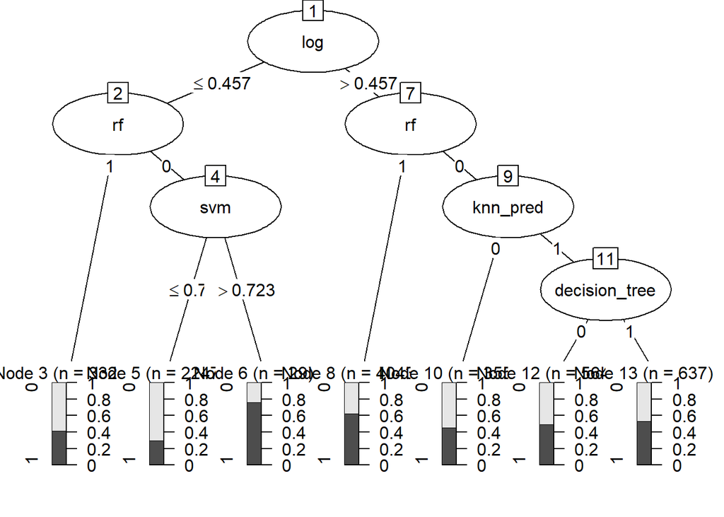

```r
plot(tree_model)
```

The accuracy is 0.6197 and the final kappa is 0.2397. Using this information, we see that the final comprehensive model was able to perform slightly better than other individual models, like the decision tree. Overall, we notice that the stacked model was able to perform more accurately and yield better predictive performance, as it combined predictions from all models into a single dataframe for training purposes.

The accuracy and kappa above are the final metrics for the prediction of track popularity given Spotify songs with attributes such as danceability, energy, accousticness, and more.

# 5 Conclusion

While our model does not have the best accuracy, with approximately 62%, it is still better than blindly guessing that a song is popular or not. The model is also partially generalizable with a kappa of 0.2397.

So given the above accuracy and kappa, how can this model be scaled to benefit the music industry?

In our analysis, we assume our audience to be both individual song artists and record labels. This model can be useful for song artists, as is will allow them to determine the predicted popularity of their new song given significant metrics such as loudness, accousticness, tempo, and more. Moreover, if an artist solely has an idea for a new song but has not completed it yet, this model can help to gauge the popularity of the *type* of song the artist is planning to craft.

- Danceability: 0.713
- Energy: 0.649
- Key: 9
- Loudness: -10.353
- Mode: 0
- Speechiness: 0.0586
- Accousticness: 0.113000
- Instrumentalness: 0.0453
- Liveness: 0.175
- Valence: 0.3200
- Tempo: 101.034

In terms of record labels, it makes sense to sign artists that have a high proportion of songs with high track_popularity such that their songs are predicted to be popular. This way, record labels know prior to signing a candidate that they are on track to reach a broader audience and potentially profit more from popular songs. This also allows record labels, or the music industry, to decide which songs it should spend more money advertising. By selecting songs classified as being popular by our model, these agencies reduce the risk of over-spending on unpopular songs that don’t end up collecting enough money to break even or profit.

## 5.1 Limitations

Though our model helps relate multiple distinct song attributes to a final popularity outcome, it is still possible for the model to miss-classify songs, surfacing a trade-off between false negatives (i.e. songs predicted to be unpopular but are actually popular) and false positives (i.e. songs predicted to be popular but are actually not). Due to the nature of the problem, it would be unreasonable to completely eliminate either of these, as one could make the argument that having fewer songs predicted to be popular can make the model’s decision more strict and almost guarantee that any given song whose predicted popularity is 1 will be popular; however, this degree of constraint discourages the generation and promotion of songs that would have truly been popular but missed the threshold of classification set by the model.

Additionally, since the music industry, listeners’ preferences, and types of popular songs are always changing, it may not be the case that our model could perform well in the future. In order to ensure that our model is up-to-date with new songs, we’d need to continuously train it using songs that get released. Though, given the breadth of songs available in the industry today, it may not be feasible to train our model in a timely manner such that it understands the popularity trends for every single song.

Nevertheless, we recommend our model’s final result to be used as supplemental information to guide an artist or record label’s understanding of the potential popularity of a song. Though our model may not be a complete source of truth given it has not obtained perfect accuracy, it can still serve as a critical resource to understand the general acceptance of various types of songs in the music industry given attributes such as loudness, accousticness, tempo, and many more.